# Quantifying socioeconomic inequality by race and gender

It's well established that incomes are not evenly distributed by [race](http://inequality.org/racial-inequality/) and [gender](https://www.whitehouse.gov/sites/default/files/docs/equal_pay_issue_brief_final.pdf). However, it can be hard to conceptualize the absolute difference in incomes in our everyday actions. Here, I wanted to see if I could get a more intuitive measure of income inequality, one that reflects the kinds of social judgments we make everyday: If I meet someone of Race X and Gender A, what is the probability that my income is higher?

First let's quickly load our packages

```python
%matplotlib inline
import csv
import numpy as np
import matplotlib.pyplot as plt
import os
import scipy.stats as spstats
```

The original Excel files had a lot of information that I didn't want to focus on for this first (mean incomes, mixed race people, etc.). I ended up creating two csv with race and income information--income_freq_male.csv amd income_freq_female.csv. Let's take a look at the datasets

```python
def load_income_freq(fname,disp=False):
    stereo_file=open(fname,'rU')
    stereo_read=csv.reader(stereo_file)

    if disp: print('\n');print(fname);print(stereo_read.next())
    all_freq=[]
    for row in stereo_read:
        if disp:print(row)
        to_int=map(int,row[1:])
        all_freq.append(to_int)

    return np.array(all_freq)


all_count_female=load_income_freq('income_freq_female.csv',disp=True)
all_count_male=load_income_freq('income_freq_male.csv',disp=True)
races=['White', 'Black', 'Asian', 'Hispanic']
```

```
income_freq_female.csv
['', 'White', 'Black', 'Asian', 'Hispanic']
['..Under $2,500', '21958', '4039', '2444', '6804']
['..$2,500 to $4,999', '3262', '721', '216', '776']
['..$5,000 to $7,499', '4296', '794', '346', '968']
['..$7,500 to $9,999', '5494', '1163', '347', '1207']
['..$10,000 to $12,499', '6509', '1294', '418', '1240']
['..$12,500 to $14,999', '4447', '821', '248', '802']
['..$15,000 to $17,499', '4797', '916', '283', '1015']
['..$17,500 to $19,999', '3657', '635', '170', '619']
['..$20,000 to $22,499', '4876', '907', '302', '1118']
['..$22,500 to $24,999', '2985', '589', '147', '490']
['..$25,000 to $27,499', '3783', '711', '236', '636']
['..$27,500 to $29,999', '2337', '468', '111', '331']
['..$30,000 to $32,499', '3876', '745', '271', '683']
['..$32,500 to $34,999', '1733', '284', '85', '239']
['..$35,000 to $37,499', '2906', '496', '211', '449']
['..$37,500 to $39,999', '1534', '291', '91', '206']
['..$40,000 to $42,499', '2901', '544', '280', '378']
['..$42,500 to $44,999', '1162', '187', '56', '134']
['..$45,000 to $47,499', '2105', '333', '93', '262']
['..$47,500 to $49,999', '1163', '188', '90', '139']
['..$50,000 to $52,499', '2170', '355', '173', '260']
['..$52,500 to $54,999', '903', '102', '43', '94']
['..$55,000 to $57,499', '1435', '205', '120', '163']
['..$57,500 to $59,999', '722', '83', '58', '45']
['..$60,000 to $62,499', '1537', '222', '138', '207']
['..$62,500 to $64,999', '603', '64', '23', '62']
['..$65,000 to $67,499', '1017', '149', '87', '86']
['..$67,500 to $69,999', '509', '58', '33', '36']
['..$70,000 to $72,499', '988', '118', '113', '88']
['..$72,500 to $74,999', '413', '58', '37', '22']
['..$75,000 to $77,499', '891', '92', '85', '64']
['..$77,500 to $79,999', '295', '36', '27', '24']
['..$80,000 to $82,499', '670', '103', '83', '72']
['..$82,500 to $84,999', '315', '41', '15', '40']
['..$85,000 to $87,499', '460', '58', '49', '33']
['..$87,500 to $89,999', '261', '27', '16', '17']
['..$90,000 to $92,499', '390', '44', '55', '40']
['..$92,500 to $94,999', '200', '17', '21', '8']
```

[output cut: 39 more lines]

```
['..$72,500 to $74,999', '697', '46', '37', '62']
['..$75,000 to $77,499', '1435', '127', '117', '160']
['..$77,500 to $79,999', '605', '45', '44', '74']
['..$80,000 to $82,499', '1419', '141', '145', '198']
['..$82,500 to $84,999', '528', '66', '24', '59']
['..$85,000 to $87,499', '792', '88', '72', '82']
['..$87,500 to $89,999', '427', '33', '27', '33']
['..$90,000 to $92,499', '1041', '100', '104', '102']
['..$92,500 to $94,999', '373', '38', '29', '31']
['..$95,000 to $97,499', '533', '49', '38', '43']
['..$97,500 to $99,999', '394', '49', '29', '29']
['..$100,000 to $149,999', '6837', '453', '695', '544']
['..$150,000 to $199,999', '2675', '121', '228', '158']
['..$200,000 to $249,999', '1105', '49', '77', '60']
['..$250,000 and above', '1503', '79', '148', '81']
```

For the time being, I'm going to collapse these two sets; I'll get back to them later

```python
all_count=all_count_female+all_count_male
```

For each of these income brackets (rows) we have the number of White, Black, Asian and Hispanic people within that bracket. Counting whether there are more wealthy/poor people of a given race isn't going to give a meaningful measure of inequality--the varying number of people in each race precludes that.

```python
all_sum=np.sum(all_count,0)
print all_sum
```

```
[204168  33904  15655  40379]
```

So let's convert these to proportions

```python
num_row=np.size(all_count,0)
all_prop=all_count.astype(float)/np.tile(all_sum.astype(float),(num_row,1))
print all_prop
```

```
[[ 0.17282336  0.22413285  0.24196742  0.26355284]
 [ 0.02494514  0.03232657  0.02395401  0.03075856]
 [ 0.03106755  0.03902194  0.03570744  0.03940167]
 [ 0.04023647  0.05828221  0.03404663  0.0470294 ]
 [ 0.04968457  0.06285394  0.0440115   0.05822333]
 [ 0.03484385  0.03958235  0.02593421  0.03464672]
 [ 0.04174993  0.04692662  0.03251357  0.05071943]
 [ 0.03223326  0.03276899  0.02459278  0.03355705]
 [ 0.04450746  0.04674965  0.03577132  0.06121994]
 [ 0.02713941  0.02902312  0.01769403  0.02583026]
 [ 0.03619078  0.03949387  0.03008623  0.04086282]
 [ 0.0224521   0.02288815  0.01577771  0.01961416]
 [ 0.03873771  0.04026074  0.033855    0.04343842]
 [ 0.01742682  0.01377419  0.01111466  0.01428961]
 [ 0.03094021  0.02887565  0.02753114  0.02850492]
 [ 0.01584479  0.01501298  0.01117854  0.01099581]
 [ 0.03183163  0.03055687  0.03219419  0.02939647]
 [ 0.0125338   0.00996933  0.00811242  0.00792491]
 [ 0.02166353  0.01875885  0.01545832  0.01669184]
 [ 0.01247012  0.01176852  0.00938997  0.00869264]
 [ 0.02591003  0.02333058  0.02625359  0.02043141]
 [ 0.01056973  0.00616446  0.00562121  0.00586939]
 [ 0.01598194  0.01294832  0.01577771  0.01087199]
 [ 0.00811097  0.00575153  0.00670712  0.00354144]
 [ 0.01966028  0.01398065  0.0189077   0.01416578]
 [ 0.0073224   0.00392284  0.00402427  0.00406152]
 [ 0.01234767  0.00814063  0.01290323  0.00777632]
 [ 0.00611261  0.00309698  0.00440754  0.00225365]
 [ 0.0132391   0.00828811  0.01520281  0.00728101]
 [ 0.0054367   0.00306748  0.00472692  0.00208029]
 [ 0.01139258  0.00645941  0.01290323  0.00554744]
 [ 0.00440813  0.0023891   0.00453529  0.002427  ]
 [ 0.01023177  0.00719679  0.01456404  0.00668664]
 [ 0.00412895  0.00315597  0.00249122  0.00245177]
 [ 0.0061322   0.00430628  0.00772916  0.00284802]
 [ 0.00336977  0.0017697   0.00274673  0.00123827]
 [ 0.00700893  0.00424729  0.0101565   0.00351668]
 [ 0.00280651  0.00162223  0.00319387  0.00096585]
 [ 0.00404079  0.00247758  0.00434366  0.00173357]
 [ 0.00295345  0.00171071  0.00389652  0.00101538]
 [ 0.04711316  0.02277017  0.06809326  0.01859878]
 [ 0.01652561  0.00525012  0.02063239  0.00480448]
 [ 0.00690118  0.00159273  0.00657937  0.00188217]
 [ 0.008973    0.00333294  0.01271159  0.00260036]]
```

Great! From a cursory glance, we can note some interesting features at the extremes. In the lowest income bracket (<\$2500) there is a lower proportion of Caucasians (minimum difference ~.05) while the other races have pretty similar proportions. In the highest income bracket (>\$250,000) there is a higher proportion of Asians (minimum difference ~.004) followed by Caucasians and then Blacks and Hispanics.

# Probability of inequality across races

Now let's get to answering the question I had in mind in the first place--What is the probability of a person from race X being wealthier than a person from race Y? To measure this, I'm going to use the proportions we just calculated to resample.

If you're unfamiliar with resampling, the code below will

1. Use the proportions we calculated above to generate a random person of race X and a random person of race Y.
2. See if the income bracket of the person from race X is higher
3. And then repeat this process many times so we can calculate the mean and confidence intervals

```python
def compare_race(race1,race2,n1,n2,fold_name):
    # Pairwise race comparison
    if not os.path.exists(fold_name):
        os.makedirs(fold_name)

    fname='comp'+str(n1)+'_'+str(n2)+'.npy'

    full_fname=os.path.join(fold_name,fname)

    if not os.path.isfile(full_fname):
        print 'Fitting '+fname
        num_income=range(0,len(race1))
        num_samp=20000
        race_comp=[]
        for its in range(0,num_samp):
            race1_choice=np.random.choice(num_income,p=race1)
            race2_choice=np.random.choice(num_income,p=race2)
            if race1_choice>race2_choice:
                race_comp.append(1)
            elif race1_choice<race2_choice:
                race_comp.append(0)
        race_comp_array=np.array(race_comp)
        np.save(full_fname,race_comp_array)
    else:
        race_comp_array=np.load(full_fname)

    return race_comp_array

def grid_prop(all_prop,fold_name):
    # Run compare_race for each race-race pairing
    num_race = np.size(all_prop,1)

    race_comp=np.zeros((num_race,num_race))
    race_equal=np.zeros((num_race,num_race))

    for race1 in range(0,num_race):
        for race2 in range(0,num_race):
            curr_race1=all_prop[:,race1]
            curr_race2=all_prop[:,race2]
            race_comp_array=compare_race(curr_race1,curr_race2,race1,race2,fold_name)
            race_comp[race1,race2]=np.mean(race_comp_array)

    return race_comp

all_grid_greater=grid_prop(all_prop,'comp_race')
```

And now let's make it pretty

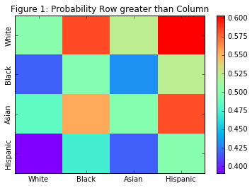

```python
def heatmap_prop(all_grid,ttle,group_names):
    fig1 = plt.figure(2)
    fig1.set_facecolor('white')
    plt.clf()
    prop_plot=plt.imshow(all_grid, aspect='auto', interpolation='nearest')
    prop_plot.set_cmap('rainbow')
    xlabels = group_names
    plt.xticks(range(len(group_names)), xlabels, rotation='horizontal')

    ylabels = group_names
    plt.yticks(range(len(group_names)), ylabels, rotation='vertical')

    plt.title(ttle)

    plt.colorbar()
    plt.show()

heatmap_prop(all_grid_greater,'Figure 1: Probability Row greater than Column',races)
```

And we get a really fascinating summary of inequality across races. There's a good amount going on here. Along the diagonal we have Probability=.5, since we're comparing two samples from the same race. Essentially, White and Asian incomes are roughly on par (lime green at (0,2)), but both groups tend to make more than Blacks and Hispanics (red squares). Taking a finer layer of granularity, Whites make *very slightly* more than Asians and Hispanics make a bit less than Blacks.

And for thoroughness, let's see whether these differences are consistent once we separate based on gender. First the females

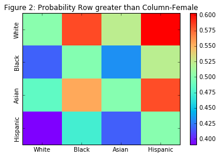

```python
all_sum_female=np.sum(all_count_female,0)
num_row=np.size(all_count_female,0)
all_prop_female=all_count_female.astype(float)/np.tile(all_sum_female.astype(float),(num_row,1))
all_grid_greater_female=grid_prop(all_prop_female,'comp_race_female')

heatmap_prop(all_grid_greater,'Figure 2: Probability Row greater than Column-Female',races)
```

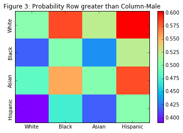

```python
all_sum_male=np.sum(all_count_male,0)
num_row=np.size(all_count_male,0)
all_prop_male=all_count_male.astype(float)/np.tile(all_sum_male.astype(float),(num_row,1))
all_grid_greater_male=grid_prop(all_prop_male,'comp_race_male')

heatmap_prop(all_grid_greater,'Figure 3: Probability Row greater than Column-Male',races)
```

# What about gender?

Of course, we can also use this same procedure to compare people from different genders

```python
count_gender=np.transpose(np.array([np.sum(all_count_male,1),np.sum(all_count_female,1)]))
genders=['Male','Female']
print count_gender
```

```
[[22069 35245]
 [ 2831  4975]
 [ 3412  6404]
 [ 4412  8211]
 [ 5854  9461]
 [ 3943  6318]
 [ 5661  7011]
 [ 4351  5081]
 [ 6501  7203]
 [ 3634  4211]
 [ 5483  5366]
 [ 3152  3247]
 [ 5983  5575]
 [ 2435  2341]
 [ 4816  4062]
 [ 2241  2122]
 [ 5123  4103]
 [ 1805  1539]
 [ 3182  2793]
 [ 1863  1580]
 [ 4359  2958]
 [ 1550  1142]
 [ 2465  1923]
 [ 1191   908]
 [ 3252  2104]
 [ 1103   752]
 [ 1974  1339]
 [  877   636]
 [ 2209  1307]
 [  842   530]
 [ 1839  1132]
 [  768   382]
 [ 1903   928]
 [  677   411]
 [ 1034   600]
 [  520   321]
 [ 1347   529]
 [  471   246]
 [  663   384]
 [  501   262]
 [ 8529  3679]
 [ 3182   887]
 [ 1291   351]
 [ 1811   438]]
```

```python
num_row=np.size(count_gender,0)
sum_gender=np.sum(count_gender,0)
prop_gender=count_gender.astype(float)/np.tile(sum_gender.astype(float),(num_row,1))
all_grid_greater_gender=grid_prop(prop_gender,'comp_gender')
```

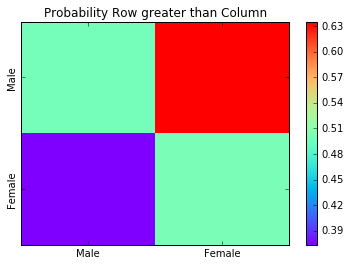

```python
heatmap_prop(all_grid_greater_gender,'Probability Row greater than Column',genders)
```

Quite frankly, plotting this as a heatmap was probably overkill...

# What about race-gender interactions?

Below we have the same code race comparison code, but modified to treat our male-female datasets separately

```python
def compare_gender_race(data,fold_name,acr=['Male','Female'],within=['White', 'Black', 'Asian', 'Hispanic']):
    # Given data1 and data2 containing different genders and the same races, run inequality resampling analysis
    num_gender=np.size(data,2)
    num_race=np.size(data,1)

    mean_great=[]
    label_great=[]
    for ig1 in range(num_gender):
        for ir1 in range(num_race):
            for ig2 in range(num_gender):
                for ir2 in range(num_race):
                    curr_1=data[:,ir1,ig1]
                    curr_2=data[:,ir2,ig2]
                    n1=acr[ig1]+within[ir1]
                    n2=acr[ig2]+within[ir2]
                    cc_race=compare_race(curr_1,curr_2,n1,n2,fold_name)
                    mean_great.append(np.mean(cc_race))
                    label_great.append(n1+'>'+n2)

    # Returns the probability gender in data 1
    return mean_great,label_great

combined_gender=np.dstack((all_prop_male,all_prop_female))
mean_great,label_great=compare_gender_race(combined_gender,'gender_race')
```

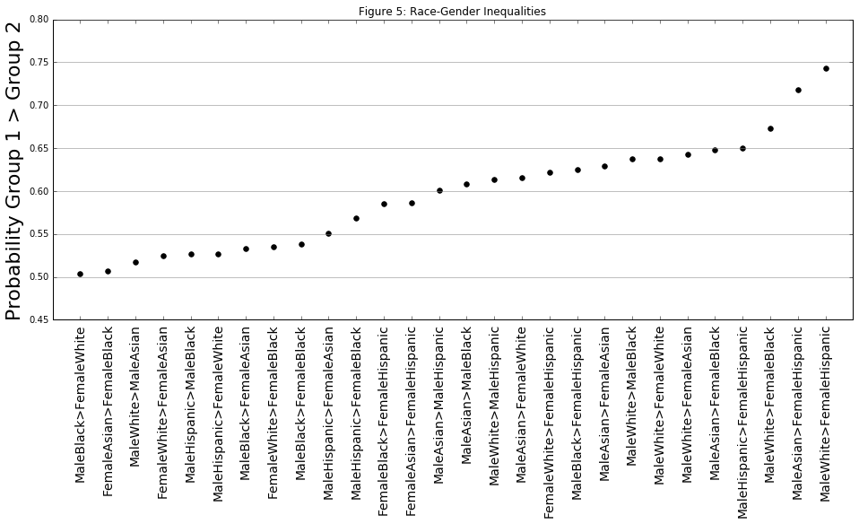

```python
def point_prop(means,ttle,group_names):
    fig1 = plt.figure(2,figsize=(16, 6))
    fig1.set_facecolor('white')
    plt.clf()
    prop_plot=plt.scatter(range(len(means)),means,s=30,color='black')
    xlabels = group_names
    plt.xticks(range(len(group_names)), xlabels, rotation='90',fontsize=14)
    plt.xlim((-1,len(group_names)))
    plt.ylabel('Probability Group 1 > Group 2',fontsize=22)
    plt.title(ttle)
    plt.grid(b=True, axis='y',which='major', color='grey', linestyle='-')

    plt.show()

rankings=np.argsort(mean_great)

mean_great2=[mean_great[i] for i in rankings]
label_great2=[label_great[i] for i in rankings]

num_include=(len(mean_great2)/2)+4
point_prop(mean_great2[num_include:],'Figure 5: Race-Gender Inequalities',label_great2[num_include:])
```

For ease of viewing, I've rank ordered the comparisons and removed same-same comparisons and the converses of the ones here. Accounting for race-gender interactions reveals some whopping disparities well beyond what we've seen before. Previously we found that Whites were more likely to make more than Hispanics (~.6) and Males were more likely to make more than Females (~.63). But the combination of the two (that is, comparing White Males to Hispanic Females) resulted in an increased probability of almost .75!

# Conclusions

People are typically very bad at estimating people's average income, making it difficult to conceptualize the magnitude of socioeconomic inequality in our society. Using this measure allows us to express these social differences more intuitively.

Comparably, in some of my other work (Lew & Vul, 2016, Knowledge and use of price distributions by populations and individuals, submitted to CogSci 2016), we found that people were really awful at estimating how much the absolute prices of objects vary but had pretty accurate knowledge of the relative dispersion of prices--that is, people know which objects have more variable prices but not how much they vary. Our probability measure of inequality may allow us to evaluate whether people themselves know *something* about how much incomes vary in our society.